# TFM_Analisis_Exploratorio

Daniel Rodrigálvarez Morente

Máster universitario en Ciencia de datos

Trabajo Final de Máster

NOTEBOOK 0. Análisis exploratorio de los datos

En este notebook realizaré el análisis exploratorio de los datos facilitados para realizar la segmentación.

Importo las librerías a utilizar en todo el proyecto

```python
import sys
sys.path.append('../src')

import pandas as pd
import matplotlib.pyplot as plt
import seaborn as sns
import os

import eda

%matplotlib inline
sns.set_theme(color_codes=True)
```

# 1. Carga de los datos

Cargo los datasets proporcionados para realizar el trabajo

```python
clientes = pd.read_csv('../data/raw/CLIENTES.txt', encoding='latin-1', sep='|')
clientes = pd.DataFrame(clientes)

clientes_email = pd.read_csv('../data/raw/CLIENTES_PF_EMAIL_RELACIONES.txt', encoding='latin-1', sep='|')
clientes_email = pd.DataFrame(clientes_email)

consultas = pd.read_csv('../data/raw/CONSULTAS.txt', encoding='latin-1', sep='|', low_memory=False)
consultas = pd.DataFrame(consultas)

departamentos = pd.read_csv('../data/raw/DEPARTAMENTOS.txt', encoding='latin-1', sep='|')
departamentos = pd.DataFrame(departamentos)

sectores = pd.read_csv('../data/raw/SECTORES.txt', encoding='latin-1', sep='|')
sectores = pd.DataFrame(sectores)

ventas = pd.read_csv('../data/raw/VENTAS.txt', encoding='latin-1', sep='|')
ventas = pd.DataFrame(ventas)
```

# 2. Revisión inicial de los datos

Ejecuto la función propia creado en el módulo "funciones" para obtener una descripción de cada dataframe

```python
eda.explorar_dataframe(clientes)
```

```
============ Información General ============

<class 'pandas.core.frame.DataFrame'>
RangeIndex: 9512 entries, 0 to 9511
Data columns (total 17 columns):
 #   Column                  Non-Null Count  Dtype
---  ------                  --------------  -----
 0   ID                      9512 non-null   int64
 1   FECHA_REGISTRO          9512 non-null   object
 2   CANAL_REGISTRO          9512 non-null   object
 3   FECHA_CLIENTE           9512 non-null   object
 4   CLIENTEPORCAMPAÑAEMAIL  9512 non-null   int64
 5   FORMAJURIDICA           9512 non-null   object
 6   SECTOR                  9512 non-null   object
 7   DESC_SECTOR             9512 non-null   object
 8   ESTADO                  9512 non-null   object
 9   DEPARTAMENTO            3912 non-null   object
 10  TAMAÑO                  3912 non-null   object
 11  ANTIGUEDAD              3912 non-null   object
 12  DIASCLIENTE             9512 non-null   int64
 13  CONSUMOSTOTAL           9512 non-null   int64
 14  EMPRESASUNICAS_CONSULT  9512 non-null   int64
 15  NUM_COMPRAS             9512 non-null   int64
 16  IMPORTE_COMPRAS         9512 non-null   int64
dtypes: int64(7), object(10)
memory usage: 1.2+ MB
None


============ Primeras Filas ============

        ID      FECHA_REGISTRO CANAL_REGISTRO       FECHA_CLIENTE  \
0  6384286  15/3/2017 15:24:29            WEB  15/3/2017 15:36:22
1  6384667  15/3/2017 19:18:31            WEB   8/3/2018 11:01:32
2  6389279  21/3/2017 11:39:08            WEB  21/3/2017 11:39:11
3  6387954  18/3/2017 19:47:34    Directorios  24/5/2017 22:05:19
4  6383269   15/3/2017 6:58:58    Directorios   15/3/2017 7:07:12

   CLIENTEPORCAMPAÑAEMAIL   FORMAJURIDICA SECTOR  \
0                       0  PERSONA FISICA      9
```

[output cut: 92 more lines]

```
ESTADO                       0
DEPARTAMENTO              5600
TAMAÑO                    5600
ANTIGUEDAD                5600
DIASCLIENTE                  0
CONSUMOSTOTAL                0
EMPRESASUNICAS_CONSULT       0
NUM_COMPRAS                  0
IMPORTE_COMPRAS              0
dtype: int64


============ Valores Duplicados ============

No hay valores duplicados
```

Comentarios:

```python
eda.explorar_dataframe(clientes_email)
```

```
============ Información General ============

<class 'pandas.core.frame.DataFrame'>
RangeIndex: 5600 entries, 0 to 5599
Data columns (total 3 columns):
 #   Column               Non-Null Count  Dtype
---  ------               --------------  -----
 0   ID                   5600 non-null   int64
 1   EMPRESASCONRELACION  5600 non-null   int64
 2   TIPODOMINIOEMAIL     5600 non-null   object
dtypes: int64(2), object(1)
memory usage: 131.4+ KB
None


============ Primeras Filas ============

        ID  EMPRESASCONRELACION TIPODOMINIOEMAIL
0  9987369                    3   GOO-MS-YAH-APP
1  9987063                    2      CORPORATIVO
2  9986853                    2   GOO-MS-YAH-APP
3  9986007                    0   GOO-MS-YAH-APP
4  9985583                    6   GOO-MS-YAH-APP


============ Estadística ============

                  ID  EMPRESASCONRELACION TIPODOMINIOEMAIL
count   5.600000e+03          5600.000000             5600
unique           NaN                  NaN                3
top              NaN                  NaN   GOO-MS-YAH-APP
freq             NaN                  NaN             4507
mean    8.262917e+06             1.903929              NaN
std     1.097164e+06             5.020058              NaN
min     6.308943e+06             0.000000              NaN
25%     7.275213e+06             0.000000              NaN
50%     8.510965e+06             0.000000              NaN
75%     9.187964e+06             2.000000              NaN
max     9.987369e+06            90.000000              NaN


============ Valores Nulos ============

ID                     0
EMPRESASCONRELACION    0
TIPODOMINIOEMAIL       0
dtype: int64


============ Valores Duplicados ============

No hay valores duplicados
```

Comentarios:

- No hay datos nulos
- Hay datos extremos en el campo EMPRESASCONRELACION

```python
eda.explorar_dataframe(consultas)
```

```
============ Información General ============

<class 'pandas.core.frame.DataFrame'>
RangeIndex: 960805 entries, 0 to 960804
Data columns (total 9 columns):
 #   Column                  Non-Null Count   Dtype
---  ------                  --------------   -----
 0   IDCONSUMO               960805 non-null  int64
 1   ID                      960805 non-null  int64
 2   FECHACONSUMO            960805 non-null  object
 3   PRODUCTO                960805 non-null  object
 4   EMPCONSUL_ICI           960589 non-null  object
 5   EMPCONSUL_SECTOR        958330 non-null  object
 6   EMPCONSUL_TAMAÑO        958304 non-null  object
 7   EMPCONSUL_DEPARTAMENTO  958322 non-null  object
 8   EMPCONSUL_ESTADO        958330 non-null  object
dtypes: int64(2), object(7)
memory usage: 66.0+ MB
None


============ Primeras Filas ============

   IDCONSUMO       ID        FECHACONSUMO PRODUCTO     EMPCONSUL_ICI  \
0   76672021  7344051  19/12/2022 0:00:00    Ficha  1700503357600000
1   76672026  7344051  19/12/2022 0:00:00    Ficha  1700012074500000
2   76672035  6371831  19/12/2022 0:00:00    Ficha  1700015801700000
3   76672380  6500105  19/12/2022 0:00:00    Ficha  1700180438500000
4   76671375  7344051  19/12/2022 0:00:00    Ficha  1700547322700000

  EMPCONSUL_SECTOR EMPCONSUL_TAMAÑO EMPCONSUL_DEPARTAMENTO EMPCONSUL_ESTADO
0                I          PEQUEÑA                BOLIVAR           ACTIVA
1                C          PEQUEÑA                 BOGOTA           ACTIVA
2                C            MICRO           CUNDINAMARCA           ACTIVA
3                G          PEQUEÑA           CUNDINAMARCA           ACTIVA
4                C            MICRO                BOLIVAR           ACTIVA


============ Estadística ============

```

[output cut: 76 more lines]

```
470951  1700027840100000                G          MEDIANA
470986  1700027840100000                G          MEDIANA
470987  1700027840100000                G          MEDIANA

       EMPCONSUL_DEPARTAMENTO EMPCONSUL_ESTADO
51949               ANTIOQUIA           ACTIVA
51950               ANTIOQUIA           ACTIVA
51951               ANTIOQUIA           ACTIVA
51952               ANTIOQUIA           ACTIVA
470948              ANTIOQUIA           ACTIVA
470949              ANTIOQUIA           ACTIVA
470950              ANTIOQUIA           ACTIVA
470951              ANTIOQUIA           ACTIVA
470986              ANTIOQUIA           ACTIVA
470987              ANTIOQUIA           ACTIVA
```

Comentarios:

```python
eda.explorar_dataframe(departamentos)
```

```
============ Información General ============

<class 'pandas.core.frame.DataFrame'>
RangeIndex: 30 entries, 0 to 29
Data columns (total 1 columns):
 #   Column        Non-Null Count  Dtype
---  ------        --------------  -----
 0   DEPARTAMENTO  30 non-null     object
dtypes: object(1)
memory usage: 372.0+ bytes
None


============ Primeras Filas ============

  DEPARTAMENTO
0     AMAZONAS
1    ANTIOQUIA
2       ARAUCA
3    ATLANTICO
4       BOGOTA


============ Estadística ============

       DEPARTAMENTO
count            30
unique           30
top        AMAZONAS
freq              1


============ Valores Nulos ============

DEPARTAMENTO    0
dtype: int64


============ Valores Duplicados ============

No hay valores duplicados
```

Comentarios:

- No aporta nueva información a la tabla de clientes y en consultas porque ya tienen la descripción de los departamentos
- Es posible que se pueda prescindir de este dataframe

```python
eda.explorar_dataframe(sectores)
```

```
============ Información General ============

<class 'pandas.core.frame.DataFrame'>
RangeIndex: 23 entries, 0 to 22
Data columns (total 2 columns):
 #   Column       Non-Null Count  Dtype
---  ------       --------------  -----
 0   SECTOR       23 non-null     object
 1   DESC_SECTOR  23 non-null     object
dtypes: object(2)
memory usage: 500.0+ bytes
None


============ Primeras Filas ============

  SECTOR                                        DESC_SECTOR
0      9                                           NOSECTOR
1      A  AGRICULTURA, GANADERÍA, CAZA, SILVICULTURA Y P...
2      B                    EXPLOTACIÓN DE MINAS Y CANTERAS
3      C                          INDUSTRIAS MANUFACTURERAS
4      D  SUMINISTRO DE ELECTRICIDAD, GAS, VAPOR Y AIRE ...


============ Estadística ============

       SECTOR DESC_SECTOR
count      23          23
unique     23          23
top         9    NOSECTOR
freq        1           1


============ Valores Nulos ============

SECTOR         0
DESC_SECTOR    0
dtype: int64


============ Valores Duplicados ============

No hay valores duplicados
```

Comentarios:

- Será necesaria para cruzar con consultas, si se utiliza el dato de sector de la empresa consultada, dado que en ese dataframe los sectores figuran con su código en lugar de la descripción

```python
eda.explorar_dataframe(ventas)
```

```
============ Información General ============

<class 'pandas.core.frame.DataFrame'>
RangeIndex: 20537 entries, 0 to 20536
Data columns (total 5 columns):
 #   Column            Non-Null Count  Dtype
---  ------            --------------  -----
 0   ID                20537 non-null  int64
 1   FECHAVENTA        20537 non-null  object
 2   PRODUCTOCOMPRADO  20537 non-null  object
 3   CANALVENTA        20537 non-null  object
 4   IMPORTE           20537 non-null  int64
dtypes: int64(2), object(3)
memory usage: 802.4+ KB
None


============ Primeras Filas ============

        ID         FECHAVENTA PRODUCTOCOMPRADO CANALVENTA  IMPORTE
0  6389279  21/3/2017 0:00:00       VP Informe        WEB       22
1  6389989  21/3/2017 0:00:00       VP Informe        WEB       15
2  6329507   1/2/2017 0:00:00       VP Informe        WEB       35
3  6326580   1/2/2017 0:00:00       VP Informe        WEB       22
4  6326580   1/2/2017 0:00:00       VP Informe        WEB       22


============ Estadística ============

                  ID         FECHAVENTA PRODUCTOCOMPRADO CANALVENTA  \
count   2.053700e+04              20537            20537      20537
unique           NaN               2250                3          2
top              NaN  21/2/2022 0:00:00       VP Informe        WEB
freq             NaN                 34            18020      18478
mean    8.062244e+06                NaN              NaN        NaN
std     1.084786e+06                NaN              NaN        NaN
min     6.308943e+06                NaN              NaN        NaN
25%     7.100681e+06                NaN              NaN        NaN
50%     7.997236e+06                NaN              NaN        NaN
75%     9.012504e+06                NaN              NaN        NaN
```

[output cut: 27 more lines]

```

            ID         FECHAVENTA PRODUCTOCOMPRADO CANALVENTA  IMPORTE
0      6389279  21/3/2017 0:00:00       VP Informe        WEB       22
3      6326580   1/2/2017 0:00:00       VP Informe        WEB       22
4      6326580   1/2/2017 0:00:00       VP Informe        WEB       22
5      6326580   1/2/2017 0:00:00       VP Informe        WEB       22
30     6359991  27/2/2017 0:00:00       VP Informe        WEB       22
...        ...                ...              ...        ...      ...
20519  9324035  26/7/2023 0:00:00       VP Informe        WEB       25
20528  9203126  12/7/2023 0:00:00       VP Informe        WEB       35
20529  9203126  12/7/2023 0:00:00       VP Informe        WEB       35
20530  9203126  12/7/2023 0:00:00       VP Informe        WEB       35
20531  9203126  12/7/2023 0:00:00       VP Informe        WEB       35

[3917 rows x 5 columns]
```

Comentarios:

# 3. Corrección de los datos

## Corrección de variables tipo fecha

```python
clientes['FECHA_REGISTRO'] = pd.to_datetime(clientes['FECHA_REGISTRO'], errors='coerce', format='%d/%m/%Y %H:%M:%S')
clientes['FECHA_CLIENTE'] = pd.to_datetime(clientes['FECHA_CLIENTE'], errors='coerce', format='%d/%m/%Y %H:%M:%S')
consultas['FECHACONSUMO'] = pd.to_datetime(consultas['FECHACONSUMO'], errors='coerce', format='%d/%m/%Y %H:%M:%S')
ventas['FECHAVENTA'] = pd.to_datetime(ventas['FECHAVENTA'], errors='coerce', format='%d/%m/%Y %H:%M:%S')
```

## Eliminación de valores duplicados

```python
consultas = consultas.drop_duplicates()
ventas = ventas.drop_duplicates()
```

# 4. Revisión gráfica de las variables

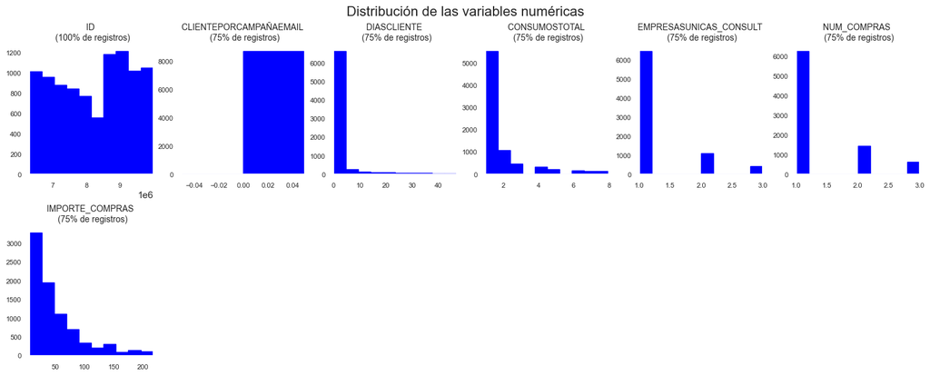

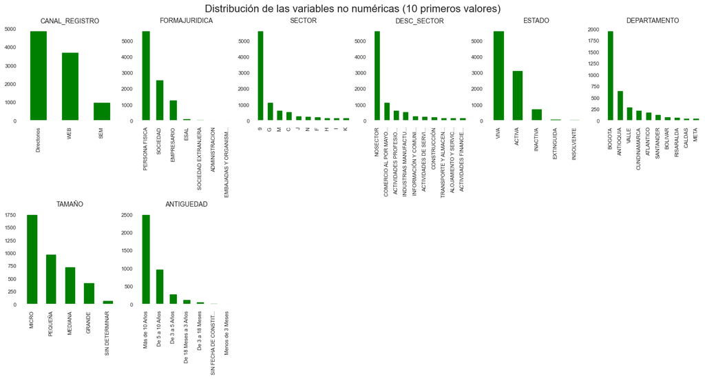

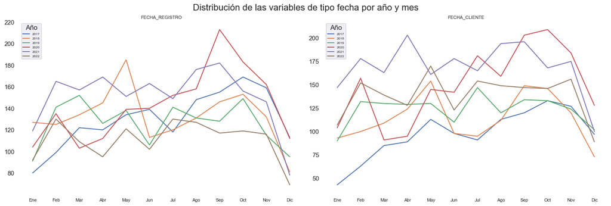

```
No hay variables booleanas para generar histogramas.
```

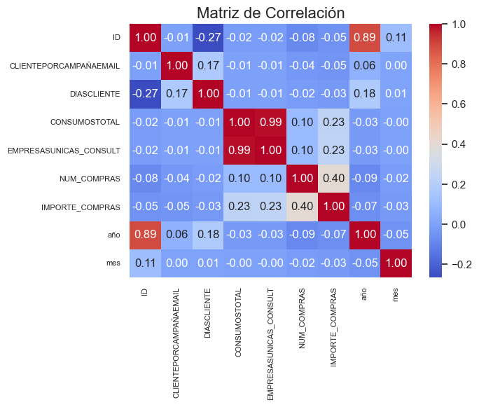

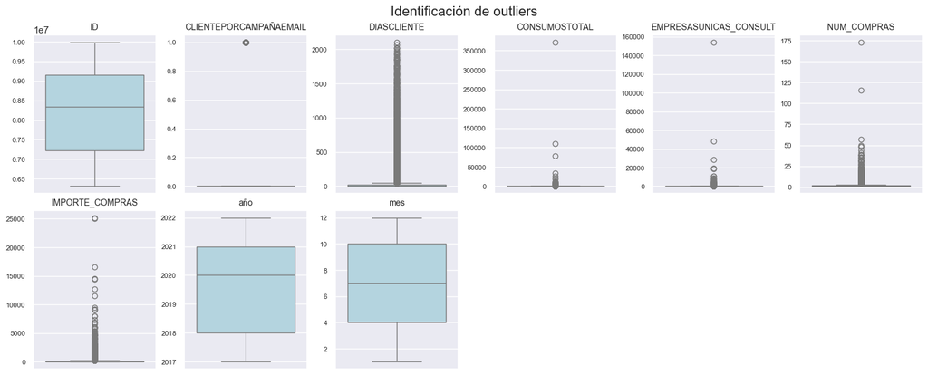

```
Número de outliers y porcentaje por variable:

ID: 0 outliers (0.00%)
CLIENTEPORCAMPAÑAEMAIL: 795 outliers (8.36%)
DIASCLIENTE: 2026 outliers (21.30%)
CONSUMOSTOTAL: 1481 outliers (15.57%)
EMPRESASUNICAS_CONSULT: 1529 outliers (16.07%)
NUM_COMPRAS: 1196 outliers (12.57%)
IMPORTE_COMPRAS: 1263 outliers (13.28%)
año: 0 outliers (0.00%)
mes: 0 outliers (0.00%)
```

```python
eda.graficos_descriptivos(clientes)
```

Comentarios:

- Hay una correlación casi perfecta entre EMPRESASUNICAS_CONSULT y CONSUMOTOTAL por lo que eliminamos la variable EMPRESASUNICAS_CONSULT al resultar redundante para el análisis
- La variable SECTOR es redundante
- Los datos PERSONA FISICA, NOSECTOR y VIVA van siempre unidos, de forma que el resto de datos de FORMAJURIDICA, SECTOR, DESC_SECTOR y ESTADO hacen referencia a sociedades
- A priori trabajaré considerando que no hay outliers, aunque los datos más extremos quizás puedan ser valores poco representativos

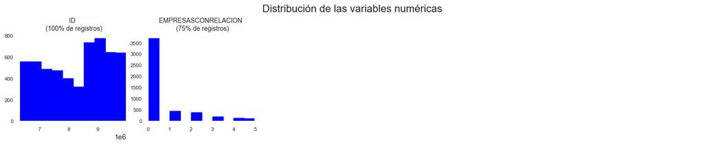

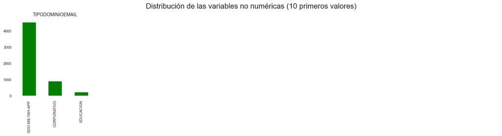

```
No hay variables tipo fecha para analizar.



No hay variables booleanas para generar histogramas.
```

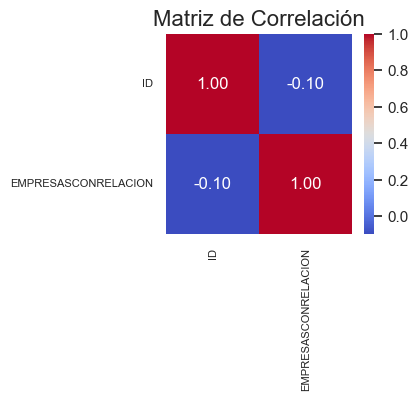

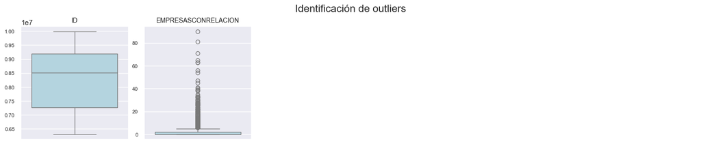

```
Número de outliers y porcentaje por variable:

ID: 0 outliers (0.00%)
EMPRESASCONRELACION: 612 outliers (10.93%)
```

```python
eda.graficos_descriptivos(clientes_email)
```

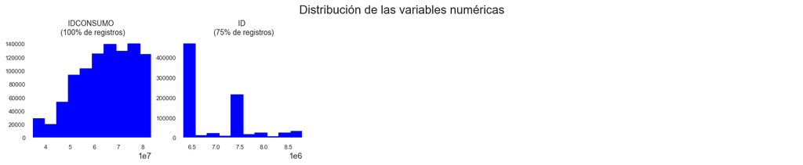

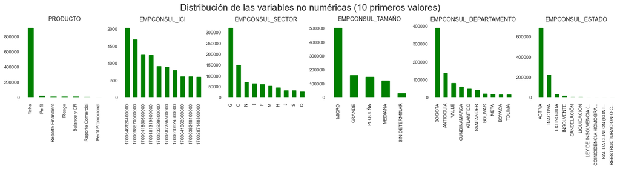

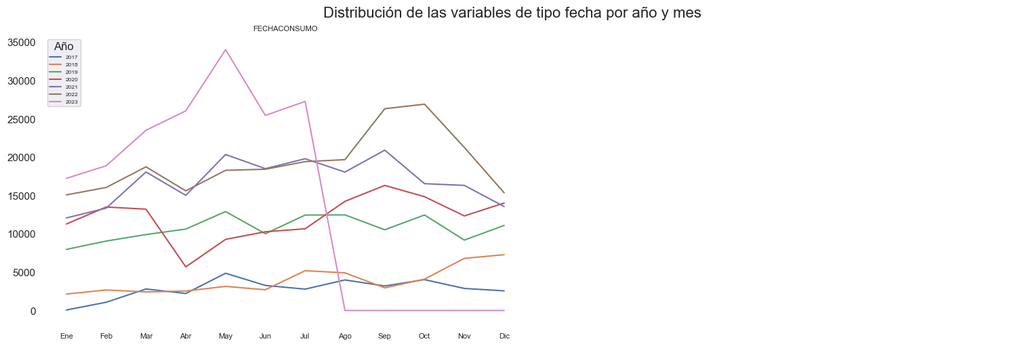

```
No hay variables booleanas para generar histogramas.
```

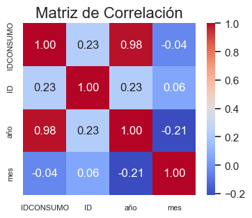

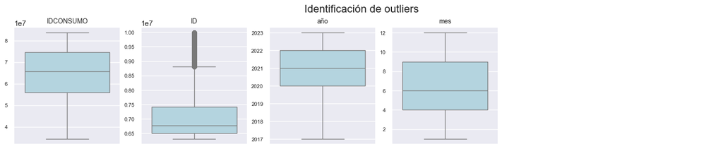

```
Número de outliers y porcentaje por variable:

IDCONSUMO: 0 outliers (0.00%)
ID: 121461 outliers (12.64%)
año: 0 outliers (0.00%)
mes: 0 outliers (0.00%)
```

```python
eda.graficos_descriptivos(consultas)
```

```
No hay variables numéricas para generar histogramas.
```

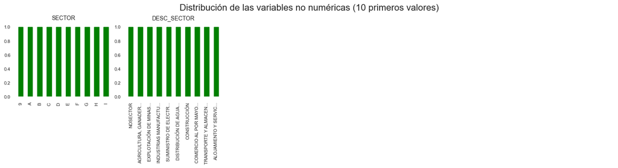

```
No hay variables tipo fecha para analizar.



No hay variables booleanas para generar histogramas.



No hay suficientes variables numéricas para generar una matriz de correlación.



No hay variables numéricas para revisar outliers.
```

```python
eda.graficos_descriptivos(sectores)
```

```
No hay variables numéricas para generar histogramas.
```

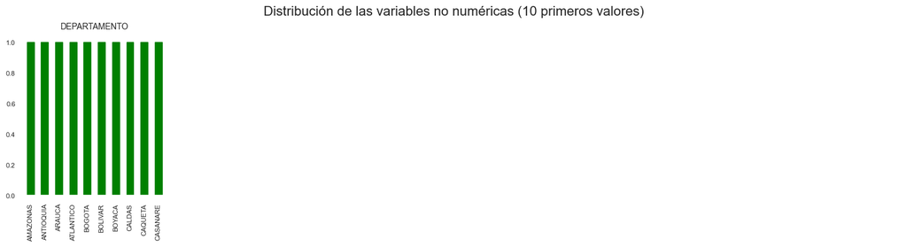

```
No hay variables tipo fecha para analizar.



No hay variables booleanas para generar histogramas.



No hay suficientes variables numéricas para generar una matriz de correlación.



No hay variables numéricas para revisar outliers.
```

```python
eda.graficos_descriptivos(departamentos)
```

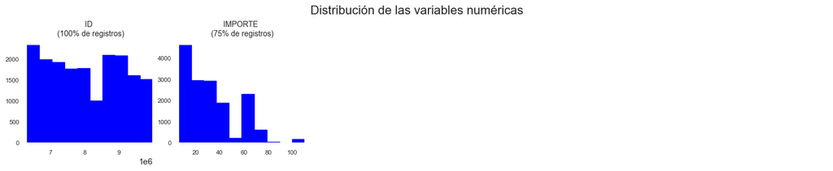

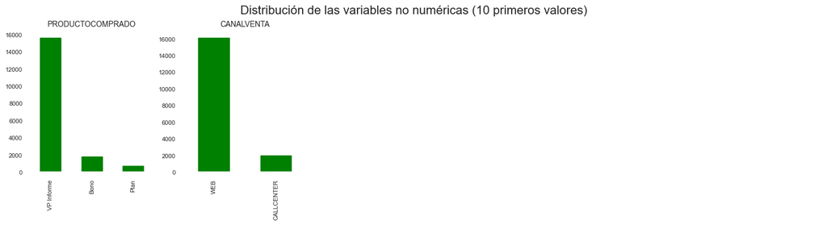

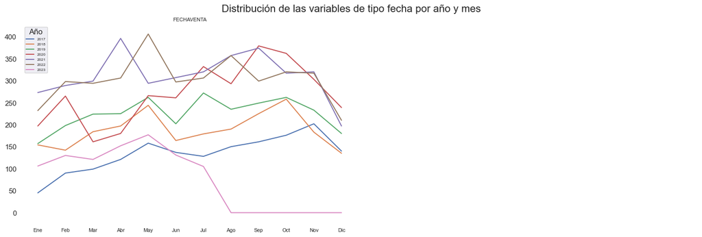

```
No hay variables booleanas para generar histogramas.
```

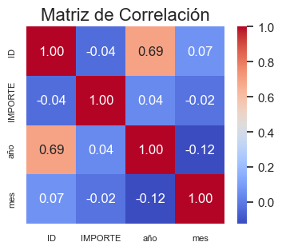

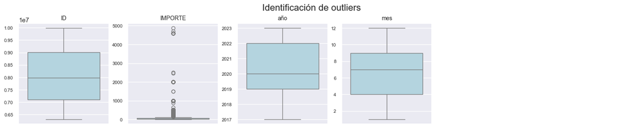

```
Número de outliers y porcentaje por variable:

ID: 0 outliers (0.00%)
IMPORTE: 2408 outliers (13.30%)
año: 0 outliers (0.00%)
mes: 0 outliers (0.00%)
```

```python
eda.graficos_descriptivos(ventas)
```

# 5. Modificación y creación de variables

Clientes

- Días transcurridos desde que se registra hasta que pasa a ser cliente (primera compra)

Ventas

- Trasponer la variable PRODUCTOCOMPRADO vs ID
- Eliminar los registros CANALVENTA = CALLCENTER
- Revisar si hay correlación entre PRODUCTOCOMPRADO e IMPORTE
- Crear una variable para registrar si se renueva un tipo de compra
- Crear una variable para registrar si hay up-selling en un cliente (hay que definir un criterio: VP Informe - Plan - Bono)

Consultas

- Trasponer la variable PRODUCTO vs ID (permitirá identificar el tipo producto para identificar los que se venden más)
- Inicialmente no considero más variables por lo que elimino el resto

## Clientes

Elimino variable irrelevantes

```python
clientes = clientes.drop(['EMPRESASUNICAS_CONSULT'], axis=1)
clientes = clientes.drop(['SECTOR'], axis=1)
```

```python
len(clientes.columns)
```

```
17
```

## Ventas

Elimino los registros correspondientes a CALLCENTER dado que están fuera del análisis y elimino la variable CANALVENTA ya que pasará a tener un valor único

```python
ventas = ventas[ventas['CANALVENTA'] != 'CALLCENTER']
ventas = ventas.drop(['CANALVENTA'], axis=1)
```

Reviso la distribución del número de ventas por cliente en diferentes periodos

[output not shown]

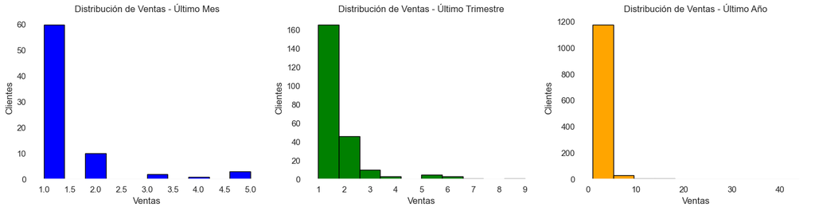

```python
# Calculo las fechas límite para cada período
hoy = pd.to_datetime('2023-07-27')
ultimo_mes = hoy - pd.DateOffset(months=1)
ultimos_3m = hoy - pd.DateOffset(months=3)
ultimos_12m = hoy - pd.DateOffset(years=1)

# Filtro las ventas para cada período
ventas_mes = ventas[ventas['FECHAVENTA'] >= ultimo_mes].groupby('ID').size()
ventas_3m = ventas[ventas['FECHAVENTA'] >= ultimos_3m].groupby('ID').size()
ventas_12m = ventas[ventas['FECHAVENTA'] >= ultimos_12m].groupby('ID').size()

# Calculo el promedio de ventas para cada período
promedio_mes = ventas_mes.mean()
promedio_3m = ventas_3m.mean()
promedio_12m = ventas_12m.mean()

print('Clientes con ventas:', len(consultas.groupby('ID')))
print('Clientes con ventas el último año:', len(ventas_12m))
print('Clientes con ventas el último trimestre:', len(ventas_3m))
print('Clientes con ventas el último mes:', len(ventas_mes))
print('\n')
print(f"Promedio de ventas del último mes: {promedio_mes:.2f}")
print(f"Promedio de ventas del último trimestre: {promedio_3m:.2f}")
print(f"Promedio de ventas del último año: {promedio_12m:.2f}")
print('\n')

# Genero histogramas
plt.figure(figsize=(15, 4))

# Histograma del último mes
plt.subplot(1, 3, 1, facecolor='white')
plt.hist(ventas_mes, bins=10, color='blue', edgecolor='black')
plt.title('Distribución de Ventas - Último Mes')
plt.xlabel('Ventas')
plt.ylabel('Clientes')

# Histograma del último trimestre
plt.subplot(1, 3, 2, facecolor='white')
plt.hist(ventas_3m, bins=10, color='green', edgecolor='black')
plt.title('Distribución de Ventas - Último Trimestre')
plt.xlabel('Ventas')
plt.ylabel('Clientes')

# Histograma del último año
plt.subplot(1, 3, 3, facecolor='white')
plt.hist(ventas_12m, bins=10, color='orange', edgecolor='black')
plt.title('Distribución de Ventas - Último Año')
plt.xlabel('Ventas')
plt.ylabel('Clientes')

plt.tight_layout()
plt.show()
```

```python
ventas_periodos_0 = pd.merge(pd.DataFrame(ventas_mes.describe()), pd.DataFrame(ventas_3m.describe()), left_index=True, right_index=True)
ventas_periodos = pd.merge(ventas_periodos_0, pd.DataFrame(ventas_12m.describe()), left_index=True, right_index=True)
ventas_periodos.columns = ['mes', '3m', '12m']
ventas_periodos
```

|  | mes | 3m | 12m |
| --- | --- | --- | --- |
| count | 76.000000 | 235.000000 | 1226.000000 |
| mean | 1.381579 | 1.527660 | 1.776509 |
| std | 0.923286 | 1.137117 | 2.153832 |
| min | 1.000000 | 1.000000 | 1.000000 |
| 25% | 1.000000 | 1.000000 | 1.000000 |
| 50% | 1.000000 | 1.000000 | 1.000000 |
| 75% | 1.000000 | 2.000000 | 2.000000 |
| max | 5.000000 | 9.000000 | 44.000000 |

```python
n = 10

ventas_mayores_0 = pd.merge(pd.DataFrame(ventas_mes.nlargest(n)), pd.DataFrame(ventas_3m.nlargest(n)), left_index=True, right_index=True, how='outer')
ventas_mayores = pd.merge(ventas_mayores_0, pd.DataFrame(ventas_12m.nlargest(n)), left_index=True, right_index=True, how='outer')
ventas_mayores.columns = ['mes', '3m', '12m']
ventas_mayores.sort_values(
    by=['mes', '3m', '12m'],
    ascending=[False, False, False])
```

| ID | mes | 3m | 12m |
| --- | --- | --- | --- |
| 8125558 | 5.0 | 6.0 | 44.0 |
| 9357411 | 5.0 | 5.0 | 15.0 |
| 9966537 | 5.0 | 5.0 | NaN |
| 9153273 | 4.0 | 9.0 | 15.0 |
| 7802352 | 3.0 | 7.0 | 19.0 |
| 8888045 | 3.0 | 6.0 | NaN |
| 7196762 | 2.0 | NaN | 14.0 |
| 6611817 | 2.0 | NaN | NaN |
| 6835847 | 2.0 | NaN | NaN |
| 7824684 | 2.0 | NaN | NaN |
| 7697432 | NaN | 6.0 | 11.0 |
| 9735832 | NaN | 5.0 | 20.0 |
| 9333245 | NaN | 5.0 | NaN |
| 9680206 | NaN | 5.0 | NaN |
| 9172386 | NaN | NaN | 15.0 |
| 9557508 | NaN | NaN | 15.0 |
| 7361111 | NaN | NaN | 11.0 |

Traspongo la variable PRODUCTOCOMPRADO de la tabla ventas

```python
df_pivot = ventas.copy()

# Utilizo pd.get_dummies para transformar los valores únicos en variables
df_pivot = pd.get_dummies(df_pivot, columns=['PRODUCTOCOMPRADO'], prefix='', prefix_sep='')

# Agrup por ID y FECHAVENTA, aplicando la agregación máxima para cada variable nueva
ventas = df_pivot.groupby(['ID', 'FECHAVENTA', 'IMPORTE']).max().reset_index()

print(ventas.head(10))
```

```
        ID FECHAVENTA  IMPORTE   año  mes   Bono   Plan  VP Informe
0  6308943 2017-01-02       21  2017    1  False  False        True
1  6309102 2017-01-11       22  2017    1  False  False        True
2  6309127 2017-01-02       15  2017    1  False  False        True
3  6309127 2017-01-02       21  2017    1  False  False        True
4  6309127 2017-02-09       15  2017    2  False  False        True
5  6309127 2017-02-24       22  2017    2  False  False        True
6  6309127 2017-05-14       35  2017    5  False  False        True
7  6309127 2018-04-19       35  2018    4  False  False        True
8  6309127 2018-08-09       25  2018    8  False  False        True
9  6309127 2018-08-09       35  2018    8  False  False        True
```

```python
ventas.head()
```

|  | ID | FECHAVENTA | IMPORTE | año | mes | Bono | Plan | VP Informe |
| --- | --- | --- | --- | --- | --- | --- | --- | --- |
| 0 | 6308943 | 2017-01-02 | 21 | 2017 | 1 | False | False | True |
| 1 | 6309102 | 2017-01-11 | 22 | 2017 | 1 | False | False | True |
| 2 | 6309127 | 2017-01-02 | 15 | 2017 | 1 | False | False | True |
| 3 | 6309127 | 2017-01-02 | 21 | 2017 | 1 | False | False | True |
| 4 | 6309127 | 2017-02-09 | 15 | 2017 | 2 | False | False | True |

Creo una nueva tabla de ventas con un registro por cada cliente y las variables de resumen:

- PRIMERA_FECHAVENTA. La fecha de la primera venta al cliente
- ULTIMA_FECHAVENTA. La fecha de la última venta al cliente
- IMPORTE_PROMEDIO. Importe promedio gastado en el total de ventas
- IMPORTE_TOTAL. Importe total gastado por el cliente
- VENTAS_TOTAL. Número de ventas realizadas al cliente
- BONOS_TOTAL. Número de bonos vendidos al cliente
- PLANES_TOTAL. Número de planes vendidos al cliente
- VPIs_TOTAL. Número de VP Informes vendidos al cliente
- BONO. Indica si hay al menos una venta de bono
- PLAN. Indica si hay al menos una venta de plan
- VPI. Indica si hay al menor una venta de VP Informe

```python
ventas_resumen = ventas.groupby('ID').agg(
    PRIMERA_FECHAVENTA=('FECHAVENTA', 'min'),
    ULTIMA_FECHAVENTA=('FECHAVENTA', 'max'),
    IMPORTE_PROMEDIO=('IMPORTE', 'mean'),
    IMPORTE_TOTAL=('IMPORTE', 'sum'),
    VENTAS_TOTAL=('FECHAVENTA', 'count'),
    BONOS_TOTAL=('Bono', 'sum'),
    PLANES_TOTAL=('Plan', 'sum'),
    VPI_TOTAL=('VP Informe', 'sum'),
    BONO=('Bono', 'any'),
    PLAN=('Plan', 'any'),
    VPI=('VP Informe', 'any')
).reset_index()

ventas_resumen.head()
```

|  | ID | PRIMERA_FECHAVENTA | ULTIMA_FECHAVENTA | IMPORTE_PROMEDIO | IMPORTE_TOTAL | VENTAS_TOTAL | BONOS_TOTAL | PLANES_TOTAL | VPI_TOTAL | BONO | PLAN | VPI |
| --- | --- | --- | --- | --- | --- | --- | --- | --- | --- | --- | --- | --- |
| 0 | 6308943 | 2017-01-02 | 2017-01-02 | 21.000000 | 21 | 1 | 0 | 0 | 1 | False | False | True |
| 1 | 6309102 | 2017-01-11 | 2017-01-11 | 22.000000 | 22 | 1 | 0 | 0 | 1 | False | False | True |
| 2 | 6309127 | 2017-01-02 | 2022-12-17 | 23.181818 | 255 | 11 | 0 | 0 | 11 | False | False | True |
| 3 | 6309222 | 2019-07-19 | 2019-11-22 | 25.000000 | 125 | 5 | 0 | 0 | 5 | False | False | True |
| 4 | 6309425 | 2017-01-03 | 2017-01-03 | 15.000000 | 15 | 1 | 0 | 0 | 1 | False | False | True |

Añado el campo FORMAJURIDICA de la tabla clientes

```python
ventas_resumen = pd.merge(ventas_resumen, clientes[['ID', 'FORMAJURIDICA']], on='ID', how='left')
```

```python
ventas_resumen.info()
```

```
<class 'pandas.core.frame.DataFrame'>
RangeIndex: 8861 entries, 0 to 8860
Data columns (total 13 columns):
 #   Column              Non-Null Count  Dtype
---  ------              --------------  -----
 0   ID                  8861 non-null   int64
 1   PRIMERA_FECHAVENTA  8861 non-null   datetime64[ns]
 2   ULTIMA_FECHAVENTA   8861 non-null   datetime64[ns]
 3   IMPORTE_PROMEDIO    8861 non-null   float64
 4   IMPORTE_TOTAL       8861 non-null   int64
 5   VENTAS_TOTAL        8861 non-null   int64
 6   BONOS_TOTAL         8861 non-null   int64
 7   PLANES_TOTAL        8861 non-null   int64
 8   VPI_TOTAL           8861 non-null   int64
 9   BONO                8861 non-null   bool
 10  PLAN                8861 non-null   bool
 11  VPI                 8861 non-null   bool
 12  FORMAJURIDICA       8861 non-null   object
dtypes: bool(3), datetime64[ns](2), float64(1), int64(6), object(1)
memory usage: 718.4+ KB
```

Calculo nuevas variables frecuencia de compra y total comprado de un cliente en un periodo

```python
fecha_inicial = pd.to_datetime('28-07-2022', format='%d-%m-%Y')
fecha_final = pd.to_datetime('28-07-2023', format='%d-%m-%Y')

# Filtro las ventas de la tabla de ventas original dentro del periodo
df_periodo = ventas[(ventas['FECHAVENTA'] >= fecha_inicial) & (ventas['FECHAVENTA'] <= fecha_final)]

# Agrupo por cliente y calcula las ventas totales y el importe total durante el periodo
df_periodo = df_periodo.groupby('ID').agg(
    IMPORTE_PERIODO=('IMPORTE', 'sum'),
    VENTAS_PERIODO=('FECHAVENTA', 'count'),
).reset_index()

# Añado las variable al df ventas_resumen
ventas_resumen = ventas_resumen.merge(df_periodo, on='ID', how='left')

# Calculo el importe medio del periodo
ventas_resumen['IMPORTE_PROMEDIO_PERIODO'] = ventas_resumen.apply(
    lambda row: 0 if row['IMPORTE_PERIODO'] == 0 or row['VENTAS_PERIODO'] == 0
    else row['IMPORTE_PERIODO'] / row['VENTAS_PERIODO'],
    axis=1)

ventas_resumen['FRECUENCIA_VENTA_PERIODO'] = ventas_resumen['VENTAS_PERIODO'] / 12

# Relleno los cliente que no han tenido ventas en el periodo
ventas_resumen['VENTAS_PERIODO'] = ventas_resumen['VENTAS_PERIODO'].fillna(0)
ventas_resumen['IMPORTE_PERIODO'] = ventas_resumen['IMPORTE_PERIODO'].fillna(0)
```

```python
ventas_resumen.head()
```

|  | ID | PRIMERA_FECHAVENTA | ULTIMA_FECHAVENTA | IMPORTE_PROMEDIO | IMPORTE_TOTAL | VENTAS_TOTAL | BONOS_TOTAL | PLANES_TOTAL | VPI_TOTAL | BONO | PLAN | VPI | FORMAJURIDICA | IMPORTE_PERIODO | VENTAS_PERIODO | IMPORTE_PROMEDIO_PERIODO | FRECUENCIA_VENTA_PERIODO |
| --- | --- | --- | --- | --- | --- | --- | --- | --- | --- | --- | --- | --- | --- | --- | --- | --- | --- |
| 0 | 6308943 | 2017-01-02 | 2017-01-02 | 21.000000 | 21 | 1 | 0 | 0 | 1 | False | False | True | PERSONA FISICA | 0.0 | 0.0 | NaN | NaN |
| 1 | 6309102 | 2017-01-11 | 2017-01-11 | 22.000000 | 22 | 1 | 0 | 0 | 1 | False | False | True | PERSONA FISICA | 0.0 | 0.0 | NaN | NaN |
| 2 | 6309127 | 2017-01-02 | 2022-12-17 | 23.181818 | 255 | 11 | 0 | 0 | 11 | False | False | True | PERSONA FISICA | 37.0 | 2.0 | 18.5 | 0.166667 |
| 3 | 6309222 | 2019-07-19 | 2019-11-22 | 25.000000 | 125 | 5 | 0 | 0 | 5 | False | False | True | SOCIEDAD | 0.0 | 0.0 | NaN | NaN |
| 4 | 6309425 | 2017-01-03 | 2017-01-03 | 15.000000 | 15 | 1 | 0 | 0 | 1 | False | False | True | PERSONA FISICA | 0.0 | 0.0 | NaN | NaN |

## Consultas

Reviso la distribución del número de consutlas por cliente

```
Clientes que han realizado consultas: 4315
Clientes que han realizado consultas el último año: 1152
Clientes que han realizado consultas el último trimestre: 454
Clientes que han realizado consultas el último mes: 210


Promedio de consultas del último mes: 143.89
Promedio de consultas del último trimestre: 194.73
Promedio de consultas del último año: 246.62
```

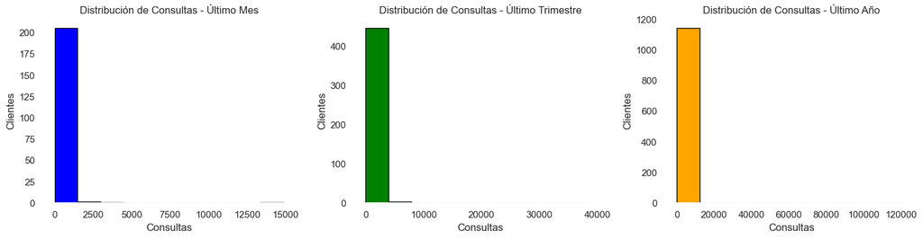

```python
# Calculo las fechas límite para cada período
hoy = pd.to_datetime('2023-07-28')
ultimo_mes = hoy - pd.DateOffset(months=1)
ultimos_3m = hoy - pd.DateOffset(months=3)
ultimos_12m = hoy - pd.DateOffset(years=1)

# Filtro las ventas para cada período
consultas_mes = consultas[consultas['FECHACONSUMO'] >= ultimo_mes].groupby('ID').size()
consultas_3m = consultas[consultas['FECHACONSUMO'] >= ultimos_3m].groupby('ID').size()
consultas_12m = consultas[consultas['FECHACONSUMO'] >= ultimos_12m].groupby('ID').size()

# Calculo el promedio de ventas para cada período
promedio_mes = consultas_mes.mean()
promedio_3m = consultas_3m.mean()
promedio_12m = consultas_12m.mean()

print('Clientes que han realizado consultas:', len(consultas.groupby('ID')))
print('Clientes que han realizado consultas el último año:', len(consultas_12m))
print('Clientes que han realizado consultas el último trimestre:', len(consultas_3m))
print('Clientes que han realizado consultas el último mes:', len(consultas_mes))
print('\n')
print(f"Promedio de consultas del último mes: {promedio_mes:.2f}")
print(f"Promedio de consultas del último trimestre: {promedio_3m:.2f}")
print(f"Promedio de consultas del último año: {promedio_12m:.2f}")
print('\n')

# Genero histogramas
plt.figure(figsize=(15, 4))

# Histograma del último mes
plt.subplot(1, 3, 1, facecolor='white')
plt.hist(consultas_mes, bins=10, color='blue', edgecolor='black')
plt.title('Distribución de Consultas - Último Mes')
plt.xlabel('Consultas')
plt.ylabel('Clientes')

# Histograma del último trimestre
plt.subplot(1, 3, 2, facecolor='white')
plt.hist(consultas_3m, bins=10, color='green', edgecolor='black')
plt.title('Distribución de Consultas - Último Trimestre')
plt.xlabel('Consultas')
plt.ylabel('Clientes')

# Histograma del último año
plt.subplot(1, 3, 3, facecolor='white')
plt.hist(consultas_12m, bins=10, color='orange', edgecolor='black')
plt.title('Distribución de Consultas - Último Año')
plt.xlabel('Consultas')
plt.ylabel('Clientes')

plt.tight_layout()
plt.show()
```

```python
consultas_periodos_0 = pd.merge(pd.DataFrame(consultas_mes.describe()), pd.DataFrame(consultas_3m.describe()), left_index=True, right_index=True)
consultas_periodos = pd.merge(consultas_periodos_0, pd.DataFrame(consultas_12m.describe()), left_index=True, right_index=True)
consultas_periodos.columns = ['mes', '3m', '12m']
consultas_periodos
```

|  | mes | 3m | 12m |
| --- | --- | --- | --- |
| count | 210.000000 | 454.00000 | 1152.000000 |
| mean | 143.885714 | 194.73348 | 246.616319 |
| std | 1086.673497 | 1975.50346 | 3860.673752 |
| min | 1.000000 | 1.00000 | 1.000000 |
| 25% | 2.000000 | 2.00000 | 2.000000 |
| 50% | 4.000000 | 4.00000 | 4.000000 |
| 75% | 12.000000 | 16.00000 | 15.250000 |
| max | 14878.000000 | 39569.00000 | 122590.000000 |

```python
n = 10

consultas_mayores_0 = pd.merge(pd.DataFrame(consultas_mes.nlargest(n)), pd.DataFrame(consultas_3m.nlargest(n)), left_index=True, right_index=True, how='outer')
consultas_mayores = pd.merge(consultas_mayores_0, pd.DataFrame(consultas_12m.nlargest(n)), left_index=True, right_index=True, how='outer')
consultas_mayores.columns = ['mes', '3m', '12m']
consultas_mayores.sort_values(
    by=['mes', '3m', '12m'],
    ascending=[False, False, False])
```

| ID | mes | 3m | 12m |
| --- | --- | --- | --- |
| 6500105 | 14878.0 | 39569.0 | 122590.0 |
| 9861622 | 3514.0 | 5502.0 | 20887.0 |
| 7421377 | 2959.0 | 8545.0 | 23673.0 |
| 7344051 | 2298.0 | 6689.0 | 25015.0 |
| 6371831 | 1020.0 | 2557.0 | 16539.0 |
| 9553294 | 943.0 | 3972.0 | 4800.0 |
| 8851816 | 890.0 | 3120.0 | 6426.0 |
| 8906798 | 479.0 | 1164.0 | 8989.0 |
| 8775114 | 447.0 | 2826.0 | 7070.0 |
| 9787839 | 255.0 | NaN | NaN |
| 7941424 | NaN | 5265.0 | 8270.0 |

Comentario:

Traspongo la variable PRODUCTO de la tabla consultas

```python
df_pivot = consultas.copy()

# Utilizo pd.get_dummies para transformar los valores únicos en variables
df_pivot = pd.get_dummies(df_pivot, columns=['PRODUCTO'], prefix='', prefix_sep='')

# Agrupo por IDCONSUMO, ID y FECHACONSUMO, aplicando la agregación máxima para cada variable nueva
consultas = df_pivot.groupby(['IDCONSUMO', 'ID', 'FECHACONSUMO']).max().reset_index()

print(consultas.head(10))
```

```
   IDCONSUMO       ID FECHACONSUMO     EMPCONSUL_ICI EMPCONSUL_SECTOR  \
0   34367922  6310095   2017-01-05  1700016805900000                B
1   34367931  6310095   2017-01-05  1700011617800000                B
2   34367933  6310095   2017-01-05  1700112371400000                C
3   34367937  6310095   2017-01-05  1700112371400000                C
4   34367939  6310095   2017-01-05               NaN              NaN
5   34367951  6310095   2017-01-05  1700043999700000                B
6   34367961  6310095   2017-01-05  1700043999700000                B
7   34387363  6311961   2017-01-09  1700095363600000                E
8   34394829  6312442   2017-01-10  1700342211300000                P
9   34428822  6314749   2017-01-13  1700045699800000                G

  EMPCONSUL_TAMAÑO EMPCONSUL_DEPARTAMENTO EMPCONSUL_ESTADO   año  mes  \
0           GRANDE                 BOGOTA           ACTIVA  2017    1
1           GRANDE                 BOGOTA           ACTIVA  2017    1
```

[output cut: 32 more lines]

Creo una nueva tabla de consultas con un registro por cada cliente y las variables de resumen:

- PRIMERA_FECHACONSUMO. La fecha del primer consumo del cliente
- ULTIMA_FECHACONSUMO. La fecha del último consumo del cliente
- CONSULTAS_TOTAL. Número total de consultas de un cliente
- BALANCEYCR_TOTAL. Número de consultas de Balance y CR realizadas por el cliente
- FICHA_TOTAL. Número de consultas de Ficha realizadas por el cliente
- PERFIL_TOTAL. Número de consultas de Perfil realizadas por el cliente
- PERFIL_PROMO_TOTAL. Número de consultas de Perfil Promocional realizadas por el cliente
- REP_CCIAL_TOTAL. Número de consultas de Reporte Comercial realizadas por el cliente
- REP_FIN_TOTAL. Número de consultas de Reporte Financiero realizadas por el cliente
- RIESGO_TOTAL. Número de consultas de Riesgo realizadas por el cliente
- BALANCEYCR. Indica si hay al menos una consulta de Balance y CR
- FICHA. Indica si hay al menos una consulta de Ficha
- PERFIL. Indica si hay al menos una consulta de Perfil
- PERFIL_PROMO. Indica si hay al menos una consulta de Perfil Promocional
- REP_CCIAL. Indica si hay al menos una consulta de Reporte Comercial
- REP_FIN. Indica si hay al menos una consulta de Reporte Financiero
- RIESGO. Indica si hay al menos una consulta de Riesgo

```python
consultas_resumen = consultas.groupby('ID').agg(
    PRIMERA_FECHACONSUMO=('FECHACONSUMO', 'min'),
    ULTIMA_FECHACONSUMO=('FECHACONSUMO', 'max'),
    CONSULTAS_TOTAL=('IDCONSUMO', 'count'),
    BALANCEYCR_TOTAL=('Balance y CR', 'sum'),
    FICHA_TOTAL=('Ficha', 'sum'),
    PERFIL_TOTAL=('Perfil', 'sum'),
    PERFIL_PROMO_TOTAL=('Perfil Promocional', 'sum'),
    REP_CCIAL_TOTAL=('Reporte Comercial', 'sum'),
    REP_FIN_TOTAL=('Reporte Financiero', 'sum'),
    RIESGO_TOTAL=('Riesgo', 'sum'),
    BALANCEYCR=('Balance y CR', 'any'),
    FICHA=('Ficha', 'any'),
    PERFIL=('Perfil', 'any'),
    PERFIL_PROMO=('Perfil Promocional', 'any'),
    REP_CCIAL=('Reporte Comercial', 'any'),
    REP_FIN=('Reporte Financiero', 'any'),
    RIESGO=('Riesgo', 'any')
).reset_index()
consultas_resumen.head()
```

|  | ID | PRIMERA_FECHACONSUMO | ULTIMA_FECHACONSUMO | CONSULTAS_TOTAL | BALANCEYCR_TOTAL | FICHA_TOTAL | PERFIL_TOTAL | PERFIL_PROMO_TOTAL | REP_CCIAL_TOTAL | REP_FIN_TOTAL | RIESGO_TOTAL | BALANCEYCR | FICHA | PERFIL | PERFIL_PROMO | REP_CCIAL | REP_FIN | RIESGO |
| --- | --- | --- | --- | --- | --- | --- | --- | --- | --- | --- | --- | --- | --- | --- | --- | --- | --- | --- |
| 0 | 6308758 | 2017-01-30 | 2017-01-30 | 10 | 0 | 5 | 0 | 5 | 0 | 0 | 0 | False | True | False | True | False | False | False |
| 1 | 6309127 | 2017-02-09 | 2022-12-17 | 22 | 2 | 13 | 3 | 0 | 1 | 0 | 3 | True | True | True | False | True | False | True |
| 2 | 6309222 | 2019-07-22 | 2019-11-22 | 9 | 0 | 4 | 0 | 0 | 0 | 0 | 5 | False | True | False | False | False | False | True |
| 3 | 6309808 | 2020-06-05 | 2021-06-08 | 15 | 1 | 9 | 0 | 0 | 2 | 3 | 0 | True | True | False | False | True | True | False |
| 4 | 6310095 | 2017-01-05 | 2017-01-05 | 7 | 0 | 5 | 0 | 0 | 0 | 2 | 0 | False | True | False | False | False | True | False |

Añado la variable FORMAJURIDICA de la tabla clientes

```python
consultas_resumen = pd.merge(consultas_resumen, clientes[['ID', 'FORMAJURIDICA']], on='ID', how='left')
consultas_resumen.head()
```

|  | ID | PRIMERA_FECHACONSUMO | ULTIMA_FECHACONSUMO | CONSULTAS_TOTAL | BALANCEYCR_TOTAL | FICHA_TOTAL | PERFIL_TOTAL | PERFIL_PROMO_TOTAL | REP_CCIAL_TOTAL | REP_FIN_TOTAL | RIESGO_TOTAL | BALANCEYCR | FICHA | PERFIL | PERFIL_PROMO | REP_CCIAL | REP_FIN | RIESGO | FORMAJURIDICA |
| --- | --- | --- | --- | --- | --- | --- | --- | --- | --- | --- | --- | --- | --- | --- | --- | --- | --- | --- | --- |
| 0 | 6308758 | 2017-01-30 | 2017-01-30 | 10 | 0 | 5 | 0 | 5 | 0 | 0 | 0 | False | True | False | True | False | False | False | NaN |
| 1 | 6309127 | 2017-02-09 | 2022-12-17 | 22 | 2 | 13 | 3 | 0 | 1 | 0 | 3 | True | True | True | False | True | False | True | PERSONA FISICA |
| 2 | 6309222 | 2019-07-22 | 2019-11-22 | 9 | 0 | 4 | 0 | 0 | 0 | 0 | 5 | False | True | False | False | False | False | True | SOCIEDAD |
| 3 | 6309808 | 2020-06-05 | 2021-06-08 | 15 | 1 | 9 | 0 | 0 | 2 | 3 | 0 | True | True | False | False | True | True | False | SOCIEDAD |
| 4 | 6310095 | 2017-01-05 | 2017-01-05 | 7 | 0 | 5 | 0 | 0 | 0 | 2 | 0 | False | True | False | False | False | True | False | SOCIEDAD |

Calculo nuevas variables frecuencia de compra y total comprado de un cliente en un periodo

```python
fecha_inicial = pd.to_datetime('28-07-2022', format='%d-%m-%Y')
fecha_final = pd.to_datetime('28-07-2023', format='%d-%m-%Y')

# Filtro las consultas de la tabla de consultas original dentro del periodo
df_periodo = consultas[(consultas['FECHACONSUMO'] >= fecha_inicial) & (consultas['FECHACONSUMO'] <= fecha_final)]

# Agrupo por cliente y calcula las consultas totales y el importe total durante el periodo
df_periodo = df_periodo.groupby('ID').agg(CONSULTAS_PERIODO=('FECHACONSUMO', 'count')).reset_index()

# Añado la columna de frecuencia de venta al df ventas_resumen
consultas_resumen = consultas_resumen.merge(df_periodo, on='ID', how='left')

consultas_resumen['FRECUENCIA_CONSULTA_PERIODO'] = consultas_resumen['CONSULTAS_PERIODO'] / 12

# Relleno los cliente que no han tenido consultas en el periodo
consultas_resumen['CONSULTAS_PERIODO'] = consultas_resumen['CONSULTAS_PERIODO'].fillna(0)
```

# 6. Creación de un dataframe único

```python
df_0 = pd.merge(clientes, ventas_resumen, on='ID', how='outer')
df = pd.merge(df_0, consultas_resumen, on='ID', how='outer')
df.head()
```

|  | ID | FECHA_REGISTRO | CANAL_REGISTRO | FECHA_CLIENTE | CLIENTEPORCAMPAÑAEMAIL | FORMAJURIDICA_x | DESC_SECTOR | ESTADO | DEPARTAMENTO | TAMAÑO | ... | BALANCEYCR | FICHA | PERFIL | PERFIL_PROMO | REP_CCIAL | REP_FIN | RIESGO | FORMAJURIDICA | CONSULTAS_PERIODO | FRECUENCIA_CONSULTA_PERIODO |
| --- | --- | --- | --- | --- | --- | --- | --- | --- | --- | --- | --- | --- | --- | --- | --- | --- | --- | --- | --- | --- | --- |
| 0 | 6308758 | NaT | NaN | NaT | NaN | NaN | NaN | NaN | NaN | NaN | ... | False | True | False | True | False | False | False | NaN | 0.0 | NaN |
| 1 | 6308943 | 2017-01-02 14:22:16 | Directorios | 2017-01-02 14:41:58 | 0.0 | PERSONA FISICA | NOSECTOR | VIVA | NaN | NaN | ... | NaN | NaN | NaN | NaN | NaN | NaN | NaN | NaN | NaN | NaN |
| 2 | 6309102 | 2017-01-02 17:10:05 | WEB | 2017-01-11 15:36:02 | 0.0 | PERSONA FISICA | NOSECTOR | VIVA | NaN | NaN | ... | NaN | NaN | NaN | NaN | NaN | NaN | NaN | NaN | NaN | NaN |
| 3 | 6309127 | 2017-01-02 17:35:53 | WEB | 2017-01-02 17:35:53 | 0.0 | PERSONA FISICA | NOSECTOR | VIVA | NaN | NaN | ... | True | True | True | False | True | False | True | PERSONA FISICA | 3.0 | 0.25 |
| 4 | 6309222 | 2017-01-03 04:07:28 | Directorios | 2019-07-19 16:17:00 | 0.0 | SOCIEDAD | ACTIVIDADES PROFESIONALES, CIENTÍFICAS Y TÉCNICAS | ACTIVA | BOGOTA | PEQUEÑA | ... | False | True | False | False | False | False | True | SOCIEDAD | 0.0 | NaN |

5 rows × 53 columns

Comparo los campos de tipo fecha para comprobar si son coherentes o debo completar datos o prescindir de alguna variable

```python
fechas = df.select_dtypes(include=['datetime64[ns]', 'datetime64'])

for i, col_i in enumerate(fechas.columns):
  for j, col_j in enumerate(fechas.columns):
      print(f"Hay {col_i} y no hay {col_j}:")
      print(len(fechas[fechas[col_i].notnull() & fechas[col_j].isnull()][[col_i, col_j]]))

fechas_faltantes = fechas[fechas['FECHA_REGISTRO'].isnull() & fechas['FECHA_CLIENTE'].isnull()]
print('\nRegistros sin FECHA_REGISTRO ni FECHA_CLIENTE')
print(len(fechas_faltantes))

fechas_faltantes_2 = fechas[fechas['FECHA_REGISTRO'].isnull() & fechas['FECHA_CLIENTE'].isnull() & fechas['PRIMERA_FECHAVENTA'].isnull()]
print('\nRegistros sin FECHA_REGISTRO ni FECHA_CLIENTE ni PRIMERA_FECHA_VENTA')
print(len(fechas_faltantes_2))

fechas_faltantes_3 = fechas[fechas['FECHA_REGISTRO'].isnull() & fechas['FECHA_CLIENTE'].isnull() & fechas['PRIMERA_FECHAVENTA'].isnull() & fechas['PRIMERA_FECHACONSUMO'].notnull()]
print('\nRegistros sin PRIMERA_FECHACONSUMO y ninguna fecha más')
print(len(fechas_faltantes_3))
```

```
Hay FECHA_REGISTRO y no hay FECHA_REGISTRO:
0
Hay FECHA_REGISTRO y no hay FECHA_CLIENTE:
0
Hay FECHA_REGISTRO y no hay PRIMERA_FECHAVENTA:
651
Hay FECHA_REGISTRO y no hay ULTIMA_FECHAVENTA:
651
Hay FECHA_REGISTRO y no hay PRIMERA_FECHACONSUMO:
5244
Hay FECHA_REGISTRO y no hay ULTIMA_FECHACONSUMO:
5244
Hay FECHA_CLIENTE y no hay FECHA_REGISTRO:
0
Hay FECHA_CLIENTE y no hay FECHA_CLIENTE:
0
Hay FECHA_CLIENTE y no hay PRIMERA_FECHAVENTA:
651
Hay FECHA_CLIENTE y no hay ULTIMA_FECHAVENTA:
651
Hay FECHA_CLIENTE y no hay PRIMERA_FECHACONSUMO:
5244
Hay FECHA_CLIENTE y no hay ULTIMA_FECHACONSUMO:
5244
Hay PRIMERA_FECHAVENTA y no hay FECHA_REGISTRO:
0
Hay PRIMERA_FECHAVENTA y no hay FECHA_CLIENTE:
0
Hay PRIMERA_FECHAVENTA y no hay PRIMERA_FECHAVENTA:
0
Hay PRIMERA_FECHAVENTA y no hay ULTIMA_FECHAVENTA:
0
Hay PRIMERA_FECHAVENTA y no hay PRIMERA_FECHACONSUMO:
5069
Hay PRIMERA_FECHAVENTA y no hay ULTIMA_FECHACONSUMO:
5069
Hay ULTIMA_FECHAVENTA y no hay FECHA_REGISTRO:
0
Hay ULTIMA_FECHAVENTA y no hay FECHA_CLIENTE:
0
```

[output cut: 26 more lines]

```
Hay ULTIMA_FECHACONSUMO y no hay ULTIMA_FECHAVENTA:
523
Hay ULTIMA_FECHACONSUMO y no hay PRIMERA_FECHACONSUMO:
0
Hay ULTIMA_FECHACONSUMO y no hay ULTIMA_FECHACONSUMO:
0

Registros sin FECHA_REGISTRO ni FECHA_CLIENTE
47

Registros sin FECHA_REGISTRO ni FECHA_CLIENTE ni PRIMERA_FECHA_VENTA
47

Registros sin PRIMERA_FECHACONSUMO y ninguna fecha más
47
```

Elimino los 47 registros que tienen consumo, pero para los cuales no tenemos datos como cliente

```python
df = df[~(df['FECHA_REGISTRO'].isnull() & df['FECHA_CLIENTE'].isnull())]
```

Dado que no es coherente que haya consulta sin que antes se haya hecho una venta, relleno los campos de PRIMERA_FECHAVENTA con el dato de PRIMERA_FECHASONSUMO para los 476 registros en que falta ese dato

```python
df.loc[df['PRIMERA_FECHAVENTA'].isnull() & df['PRIMERA_FECHACONSUMO'].notnull(), 'PRIMERA_FECHAVENTA'] = df['PRIMERA_FECHACONSUMO']
```

Creo una nueva variable con los días transcurridos entre que se produce el registro y se produce la primera venta

```python
df['DIAS_REGISTRO_CLIENTE'] = (df['FECHA_CLIENTE'] - df['FECHA_REGISTRO']).dt.days
```

Creo una nueva variable con los días transcurridos desde que se dio de alta el cliente hasta el 28 de julio de 2023 (fecha en que sitúo el análisis)

```python
df['DIAS_ANTIGUEDAD_CLIENTE'] = (pd.to_datetime('2023-07-28') - df['FECHA_CLIENTE']).dt.days
```

Creo una nueva variable con la diferencia de días entre la fecha de primera venta y la fecha de primer consumo

```python
df['DIAS_VENTA_CONSUMO'] = (df['PRIMERA_FECHACONSUMO'] - df['PRIMERA_FECHAVENTA']).dt.days
```

Creo una nueva variale con el cálculo de días desde la última compra y desde la última consutla del cliente

```python
df['RECENCIA_VENTA'] = (pd.to_datetime('2023-07-28') - df['ULTIMA_FECHAVENTA']).dt.days
df['RECENCIA_CONSUMO'] = (pd.to_datetime('2023-07-28') - df['ULTIMA_FECHACONSUMO']).dt.days
```

```python
df.info()
```

```
<class 'pandas.core.frame.DataFrame'>
Index: 9512 entries, 1 to 9558
Data columns (total 58 columns):
 #   Column                       Non-Null Count  Dtype
---  ------                       --------------  -----
 0   ID                           9512 non-null   int64
 1   FECHA_REGISTRO               9512 non-null   datetime64[ns]
 2   CANAL_REGISTRO               9512 non-null   object
 3   FECHA_CLIENTE                9512 non-null   datetime64[ns]
 4   CLIENTEPORCAMPAÑAEMAIL       9512 non-null   float64
 5   FORMAJURIDICA_x              9512 non-null   object
 6   DESC_SECTOR                  9512 non-null   object
 7   ESTADO                       9512 non-null   object
 8   DEPARTAMENTO                 3912 non-null   object
 9   TAMAÑO                       3912 non-null   object
```

[output cut: 50 more lines]

# 7. Segunda revisión de la correlación incluyendo las nuevas variables

```python
df_corr = fechas = df.select_dtypes(exclude=['object'])
eda.revision_correlacion(df_corr)
```

```
Correlaciones significativas:
ID vs FECHA_REGISTRO: 1.00
ID vs FECHA_CLIENTE: 0.90
ID vs año: 0.89
ID vs DIAS_ANTIGUEDAD_CLIENTE: -0.90
FECHA_REGISTRO vs FECHA_CLIENTE: 0.90
FECHA_REGISTRO vs año: 0.89
FECHA_REGISTRO vs DIAS_ANTIGUEDAD_CLIENTE: -0.90
FECHA_CLIENTE vs año: 0.99
FECHA_CLIENTE vs DIAS_ANTIGUEDAD_CLIENTE: -1.00
FECHA_CLIENTE vs RECENCIA_VENTA: -0.85
DIASCLIENTE vs DIAS_REGISTRO_CLIENTE: 1.00
CONSUMOSTOTAL vs CONSULTAS_TOTAL: 1.00
CONSUMOSTOTAL vs FICHA_TOTAL: 1.00
CONSUMOSTOTAL vs CONSULTAS_PERIODO: 0.99
CONSUMOSTOTAL vs FRECUENCIA_CONSULTA_PERIODO: 0.99
NUM_COMPRAS vs VENTAS_TOTAL: 0.94
NUM_COMPRAS vs VPI_TOTAL: 0.92
año vs DIAS_ANTIGUEDAD_CLIENTE: -0.99
año vs RECENCIA_VENTA: -0.84
PRIMERA_FECHAVENTA vs RECENCIA_VENTA: -0.86
ULTIMA_FECHAVENTA vs RECENCIA_VENTA: -1.00
IMPORTE_PROMEDIO vs IMPORTE_PROMEDIO_PERIODO: 0.90
VENTAS_TOTAL vs VPI_TOTAL: 0.98
VENTAS_TOTAL vs FRECUENCIA_VENTA_PERIODO: 0.81
VPI_TOTAL vs FRECUENCIA_VENTA_PERIODO: 0.81
VENTAS_PERIODO vs FRECUENCIA_VENTA_PERIODO: 1.00
PRIMERA_FECHACONSUMO vs ULTIMA_FECHACONSUMO: 1.00
ULTIMA_FECHACONSUMO vs RECENCIA_CONSUMO: -1.00
CONSULTAS_TOTAL vs FICHA_TOTAL: 1.00
CONSULTAS_TOTAL vs CONSULTAS_PERIODO: 0.99
CONSULTAS_TOTAL vs FRECUENCIA_CONSULTA_PERIODO: 0.99
FICHA_TOTAL vs CONSULTAS_PERIODO: 0.99
FICHA_TOTAL vs FRECUENCIA_CONSULTA_PERIODO: 0.99
PERFIL_TOTAL vs FRECUENCIA_CONSULTA_PERIODO: 0.80
CONSULTAS_PERIODO vs FRECUENCIA_CONSULTA_PERIODO: 1.00
DIAS_ANTIGUEDAD_CLIENTE vs RECENCIA_VENTA: 0.85
RECENCIA_VENTA vs RECENCIA_CONSUMO: 0.91
```

Comentarios:

- Dadas las correlaciones identificadas, eliminaré las siguientes variables: DIAS_ANTIGUEDAD_CLIENTE, año, DIASCLIENTE, CONSULTAS_TOTAL y NUM_COMPRAS
- Además, eliminaré las siguientes variables que no utilizaré en el análisis: mes
- Mantengo algunas variables que tienen una alta correlación pero que no utilizaré en los mismos análisis

```python
variables_a_eliminar = ['año', 'NUM_COMPRAS', 'DIAS_ANTIGUEDAD_CLIENTE', 'mes', 'DIASCLIENTE', 'CONSULTAS_TOTAL']
df = df.drop(columns=variables_a_eliminar)
```

Reinicio el índice del df

```python
df.reset_index(drop=True, inplace=True)
```

# 8. Otras revisiones de los datos

Reviso el conjunto de datos

```python
eda.explorar_dataframe(df)
```

```
============ Información General ============

<class 'pandas.core.frame.DataFrame'>
RangeIndex: 9512 entries, 0 to 9511
Data columns (total 52 columns):
 #   Column                       Non-Null Count  Dtype
---  ------                       --------------  -----
 0   ID                           9512 non-null   int64
 1   FECHA_REGISTRO               9512 non-null   datetime64[ns]
 2   CANAL_REGISTRO               9512 non-null   object
 3   FECHA_CLIENTE                9512 non-null   datetime64[ns]
 4   CLIENTEPORCAMPAÑAEMAIL       9512 non-null   float64
 5   FORMAJURIDICA_x              9512 non-null   object
 6   DESC_SECTOR                  9512 non-null   object
 7   ESTADO                       9512 non-null   object
 8   DEPARTAMENTO                 3912 non-null   object
 9   TAMAÑO                       3912 non-null   object
 10  ANTIGUEDAD                   3912 non-null   object
 11  CONSUMOSTOTAL                9512 non-null   float64
 12  IMPORTE_COMPRAS              9512 non-null   float64
 13  PRIMERA_FECHAVENTA           9337 non-null   datetime64[ns]
 14  ULTIMA_FECHAVENTA            8861 non-null   datetime64[ns]
 15  IMPORTE_PROMEDIO             8861 non-null   float64
 16  IMPORTE_TOTAL                8861 non-null   float64
 17  VENTAS_TOTAL                 8861 non-null   float64
 18  BONOS_TOTAL                  8861 non-null   float64
 19  PLANES_TOTAL                 8861 non-null   float64
 20  VPI_TOTAL                    8861 non-null   float64
 21  BONO                         8861 non-null   object
 22  PLAN                         8861 non-null   object
 23  VPI                          8861 non-null   object
 24  FORMAJURIDICA_y              8861 non-null   object
 25  IMPORTE_PERIODO              8861 non-null   float64
 26  VENTAS_PERIODO               8861 non-null   float64
 27  IMPORTE_PROMEDIO_PERIODO     1222 non-null   float64
 28  FRECUENCIA_VENTA_PERIODO     1222 non-null   float64
 29  PRIMERA_FECHACONSUMO         4268 non-null   datetime64[ns]
 30  ULTIMA_FECHACONSUMO          4268 non-null   datetime64[ns]
 31  BALANCEYCR_TOTAL             4268 non-null   float64
 32  FICHA_TOTAL                  4268 non-null   float64
```

[output cut: 199 more lines]

```
REP_FIN                        5244
RIESGO                         5244
FORMAJURIDICA                  5244
CONSULTAS_PERIODO              5244
FRECUENCIA_CONSULTA_PERIODO    8366
DIAS_REGISTRO_CLIENTE             0
DIAS_VENTA_CONSUMO             5244
RECENCIA_VENTA                  651
RECENCIA_CONSUMO               5244
dtype: int64


============ Valores Duplicados ============

No hay valores duplicados
```

Para las variables tipo object que realmente deberían ser booleanas, sustituyo los valores tipo NaN por False

```python
variables = df.select_dtypes(include=['object']).columns
variables
```

```
Index(['CANAL_REGISTRO', 'FORMAJURIDICA_x', 'DESC_SECTOR', 'ESTADO',
       'DEPARTAMENTO', 'TAMAÑO', 'ANTIGUEDAD', 'BONO', 'PLAN', 'VPI',
       'FORMAJURIDICA_y', 'BALANCEYCR', 'FICHA', 'PERFIL', 'PERFIL_PROMO',
       'REP_CCIAL', 'REP_FIN', 'RIESGO', 'FORMAJURIDICA'],
      dtype='object')
```

```python
variables = ['BONO', 'PLAN', 'VPI', 'BALANCEYCR', 'FICHA', 'PERFIL', 'PERFIL_PROMO', 'REP_CCIAL', 'REP_FIN', 'RIESGO']

for variable in variables:
    df[variable] = df[variable].map(eda.convierte_a_booleano)
```

```python
eda.explorar_dataframe(df)
```

```
============ Información General ============

<class 'pandas.core.frame.DataFrame'>
RangeIndex: 9512 entries, 0 to 9511
Data columns (total 52 columns):
 #   Column                       Non-Null Count  Dtype
---  ------                       --------------  -----
 0   ID                           9512 non-null   int64
 1   FECHA_REGISTRO               9512 non-null   datetime64[ns]
 2   CANAL_REGISTRO               9512 non-null   object
 3   FECHA_CLIENTE                9512 non-null   datetime64[ns]
 4   CLIENTEPORCAMPAÑAEMAIL       9512 non-null   float64
 5   FORMAJURIDICA_x              9512 non-null   object
 6   DESC_SECTOR                  9512 non-null   object
 7   ESTADO                       9512 non-null   object
 8   DEPARTAMENTO                 3912 non-null   object
 9   TAMAÑO                       3912 non-null   object
 10  ANTIGUEDAD                   3912 non-null   object
 11  CONSUMOSTOTAL                9512 non-null   float64
 12  IMPORTE_COMPRAS              9512 non-null   float64
 13  PRIMERA_FECHAVENTA           9337 non-null   datetime64[ns]
 14  ULTIMA_FECHAVENTA            8861 non-null   datetime64[ns]
 15  IMPORTE_PROMEDIO             8861 non-null   float64
 16  IMPORTE_TOTAL                8861 non-null   float64
 17  VENTAS_TOTAL                 8861 non-null   float64
 18  BONOS_TOTAL                  8861 non-null   float64
 19  PLANES_TOTAL                 8861 non-null   float64
 20  VPI_TOTAL                    8861 non-null   float64
 21  BONO                         9512 non-null   bool
 22  PLAN                         9512 non-null   bool
 23  VPI                          9512 non-null   bool
 24  FORMAJURIDICA_y              8861 non-null   object
 25  IMPORTE_PERIODO              8861 non-null   float64
 26  VENTAS_PERIODO               8861 non-null   float64
 27  IMPORTE_PROMEDIO_PERIODO     1222 non-null   float64
 28  FRECUENCIA_VENTA_PERIODO     1222 non-null   float64
 29  PRIMERA_FECHACONSUMO         4268 non-null   datetime64[ns]
 30  ULTIMA_FECHACONSUMO          4268 non-null   datetime64[ns]
 31  BALANCEYCR_TOTAL             4268 non-null   float64
 32  FICHA_TOTAL                  4268 non-null   float64
```

[output cut: 199 more lines]

```
REP_FIN                           0
RIESGO                            0
FORMAJURIDICA                  5244
CONSULTAS_PERIODO              5244
FRECUENCIA_CONSULTA_PERIODO    8366
DIAS_REGISTRO_CLIENTE             0
DIAS_VENTA_CONSUMO             5244
RECENCIA_VENTA                  651
RECENCIA_CONSUMO               5244
dtype: int64


============ Valores Duplicados ============

No hay valores duplicados
```

Me aseguro de que no haya variables que tengan el mismo valor para todos los registros

```python
valores_constantes = [col for col in df.columns if df[col].nunique() == 1]
valores_constantes
```

```
[]
```

# 9. Guardo los df para empezar el proceso de segmentación y genero una versión en html

```python
df.to_csv('../data/processed/datos_cliente_unico.csv', index=False, encoding='utf-8')
clientes.to_csv('../data/processed/clientes_resumen.csv', index=False, encoding='utf-8')
ventas_resumen.to_csv('../data/processed/ventas_resumen.csv', index=False, encoding='utf-8')
consultas_resumen.to_csv('../data/processed/consultas_resumen.csv', index=False, encoding='utf-8')
```

```python
notebook_path = r"D:\UOC\Assignatures\TFM\TFM_PythonProject\tfm\notebooks\TFM_Analisis_Exploratorio.ipynb"
html_path = r"D:\UOC\Assignatures\TFM\TFM_PythonProject\tfm\reports\TFM_Analisis_Exploratorio.html"

os.system(f"jupyter nbconvert --to html --template lab {notebook_path} --output {html_path}")
```